# 重賞レース予測レポート【レース終了】

作成日時: 2026/01/25 16:36:04

☞ [マニュアル(pdf)](https://ryutoro-galois.github.io/keiba-predictor/manual/manual.pdf)

☞ 過去6年の同一レース結果: [2025年](https://ryutoro-galois.github.io/keiba-predictor/report/PredResult_2025y_raceDate_20250125_20250126.html), [2024年](https://ryutoro-galois.github.io/keiba-predictor/report/PredResult_2024y_raceDate_20240121_20240121.html), [2023年](https://ryutoro-galois.github.io/keiba-predictor/report/PredResult_2023y_raceDate_20230122_20230122.html), [2022年](https://ryutoro-galois.github.io/keiba-predictor/report/PredResult_2022y_raceDate_20220123_20220123.html), [2021年](https://ryutoro-galois.github.io/keiba-predictor/report/PredResult_2021y_raceDate_20210124_20210124.html), [2020年](https://ryutoro-galois.github.io/keiba-predictor/report/PredResult_2020y_raceDate_20200126_20200126.html)

☞ 過去4週間の別レース結果: [1週前(1/18)](https://ryutoro-galois.github.io/keiba-predictor/report/PredResult_2026y_raceDate_20260118_20260118.html), [2週前(1/11-12)](https://ryutoro-galois.github.io/keiba-predictor/report/PredResult_2026y_raceDate_20260111_20260112.html), [3週前(1/4)](https://ryutoro-galois.github.io/keiba-predictor/report/PredResult_2026y_raceDate_20260104_20260104.html), [4週前(12/27-28)](https://ryutoro-galois.github.io/keiba-predictor/report/PredResult_2025y_raceDate_20251227_20251228.html)

☞ レース結果(csv): [1/24-25](https://ryutoro-galois.github.io/keiba-predictor/csv/race_result_20260124_20260125.csv)

## 【レース結果(1)】人気と着順の関係

### 【小倉牝馬ステークス(2026/01/24(土))】

【小倉牝馬ステークス(GⅢ)】  
2026/01/24(土), 10_小倉, 芝2000m

[interactive chart not shown]

### 【アメリカジョッキーC(2026/01/25(日))】

【アメリカジョッキーC(GⅡ)】  
2026/01/25(日), 06_中山, 芝右外2200m

[interactive chart not shown]

### 【プロキオンステークス(2026/01/25(日))】

[interactive chart not shown]

## 【レース結果(2)】コーナー通過順位

### 【小倉牝馬ステークス(2026/01/24(土))】

【小倉牝馬ステークス(GⅢ)】  
2026/01/24(土), 10_小倉, 芝2000m

[interactive chart not shown]

### 【アメリカジョッキーC(2026/01/25(日))】

【アメリカジョッキーC(GⅡ)】  
2026/01/25(日), 06_中山, 芝右外2200m

[interactive chart not shown]

### 【プロキオンステークス(2026/01/25(日))】

[interactive chart not shown]

## 0. 推し馬予測 (AI予測)

### 【小倉牝馬ステークス(GⅢ) 2026/01/24(土)】

- 本命(◎): 1-3着内確率(勝負強さ)が1位の馬
- 対抗(◯): 1-3着内確率が2-N位(20%程度以上)の中で予測タイムが最も速い馬
- 3番手(▲): 1-3着内確率が2-N位(20%程度以上)のでダークホース確率が最も高い馬
- 穴: ダークホース確率が上位1-M位(40%程度以上)の中で1-3着内確率が最も高い馬

| 推し馬 | 枠番 | 馬番 | 人気 | オッズ | 馬名 | 騎手 | 調教師 | 予測タイム(sec) | 1_順位 | 1-3着内確率(%) | 2_順位 | ﾀﾞｰｸﾎｰｽ確率(%) | 3_順位 |
| --- | --- | --- | --- | --- | --- | --- | --- | --- | --- | --- | --- | --- | --- |
| 本命(◎) | 8 | 16 | 8 | 17.7 | ボンドガール | 丹内祐次 | 手塚貴久 | 117.3 | 2 | 36.2 | 1 | 1.9 | 10 |
| 対抗(◯) | 4 | 8 | 2 | 3.7 | ココナッツブラウン | 北村友一 | 上村洋行 | 117.3 | 2 | 30.2 | 2 | 0.6 | 14 |
| 3番手(▲) | 8 | 17 | 1 | 3.6 | ジョスラン | Ｃ．ルメール | 鹿戸雄一 | 117.3 | 2 | 24.1 | 4 | 0.6 | 15 |
| 穴 | 2 | 4 | 10 | 23.2 | クリノメイ | 酒井学 | 須貝尚介 | 126.4 | 8 | 16.0 | 8 | 45.4 | 6 |

### 【アメリカジョッキーC(GⅡ) 2026/01/25(日)】

- 本命(◎): 1-3着内確率(勝負強さ)が1位の馬
- 対抗(◯): 1-3着内確率が2-N位(20%程度以上)の中で予測タイムが最も速い馬
- 3番手(▲): 1-3着内確率が2-N位(20%程度以上)のでダークホース確率が最も高い馬
- 穴: ダークホース確率が上位1-M位(40%程度以上)の中で1-3着内確率が最も高い馬

| 推し馬 | 枠番 | 馬番 | 人気 | オッズ | 馬名 | 騎手 | 調教師 | 予測タイム(sec) | 1_順位 | 1-3着内確率(%) | 2_順位 | ﾀﾞｰｸﾎｰｽ確率(%) | 3_順位 |
| --- | --- | --- | --- | --- | --- | --- | --- | --- | --- | --- | --- | --- | --- |
| 本命(◎) | 3 | 5 | 6 | 10.7 | マテンロウレオ | 横山典弘 | 昆貢 | 136.8 | 6.0 | 32.0 | 1 | 0.6 | 12 |
| 対抗(◯) | 2 | 3 | 5 | 8.5 | マイネルエンペラー | 戸崎圭太 | 清水久詞 | 133.6 | 2.0 | 26.0 | 2 | 0.4 | 16 |
| 3番手(▲) | 5 | 9 | 3 | 5.4 | ショウヘイ | 川田将雅 | 友道康夫 | 141.5 | 8.5 | 20.8 | 3 | 0.4 | 14 |
| 穴 | 4 | 7 | 13 | 145.0 | マイネルメモリー | 佐々木大輔 | 宮徹 | 135.6 | 4.0 | 10.3 | 9 | 65.6 | 1 |

- 本命(◎): 1-3着内確率(勝負強さ)が1位の馬
- 対抗(◯): 1-3着内確率が2-N位(20%程度以上)の中で予測タイムが最も速い馬
- 3番手(▲): 1-3着内確率が2-N位(20%程度以上)のでダークホース確率が最も高い馬
- 穴: ダークホース確率が上位1-M位(40%程度以上)の中で1-3着内確率が最も高い馬

| 推し馬 | 枠番 | 馬番 | 人気 | オッズ | 馬名 | 騎手 | 調教師 | 予測タイム(sec) | 1_順位 | 1-3着内確率(%) | 2_順位 | ﾀﾞｰｸﾎｰｽ確率(%) | 3_順位 |
| --- | --- | --- | --- | --- | --- | --- | --- | --- | --- | --- | --- | --- | --- |
| 本命(◎) | 5 | 10 | 2 | 6.0 | ジェイパームス | 鮫島克駿 | 堀宣行 | 80.3 | 2 | 40.8 | 1 | 0.4 | 14 |
| 対抗(◯) | 6 | 12 | 5 | 7.4 | シゲルショウグン | 武豊 | 大橋勇樹 | 81.0 | 4 | 36.4 | 3 | 0.4 | 12 |
| 3番手(▲) | 8 | 15 | 7 | 12.2 | セラフィックコール | 西村淳也 | 寺島良 | 86.4 | 6 | 37.8 | 2 | 1.3 | 9 |
| 穴 | 2 | 3 | 15 | 140.1 | マーブルロック | 酒井学 | 西園正都 | 80.3 | 2 | 11.1 | 8 | 44.9 | 1 |

## 1. 予測チャート (タイム/勝負強さ)

### 【小倉牝馬ステークス(GⅢ)】

2026/01/24(土), 10_小倉, 芝2000m

[interactive chart not shown]

### 【アメリカジョッキーC(GⅡ)】

2026/01/25(日), 06_中山, 芝右外2200m

[interactive chart not shown]

[interactive chart not shown]

## 2. オッズモニタリング (毎時)

### 【小倉牝馬ステークス】

[interactive chart not shown]

### 【アメリカジョッキーカップ】

[interactive chart not shown]

### 【プロキオンステークス】

[interactive chart not shown]

## 3. 出馬表

### 【小倉牝馬ステークス 2026/01/24(土) 】

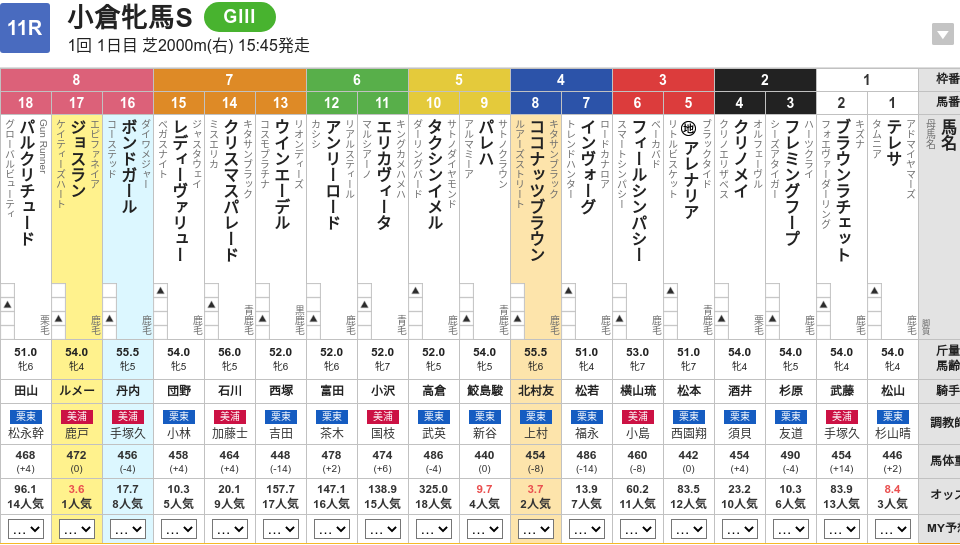

### 【アメリカジョッキーカップ 2026/01/25(日) 】

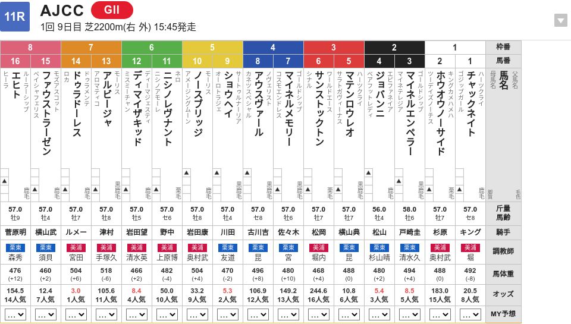

### 【プロキオンステークス 2026/01/25(日) 】

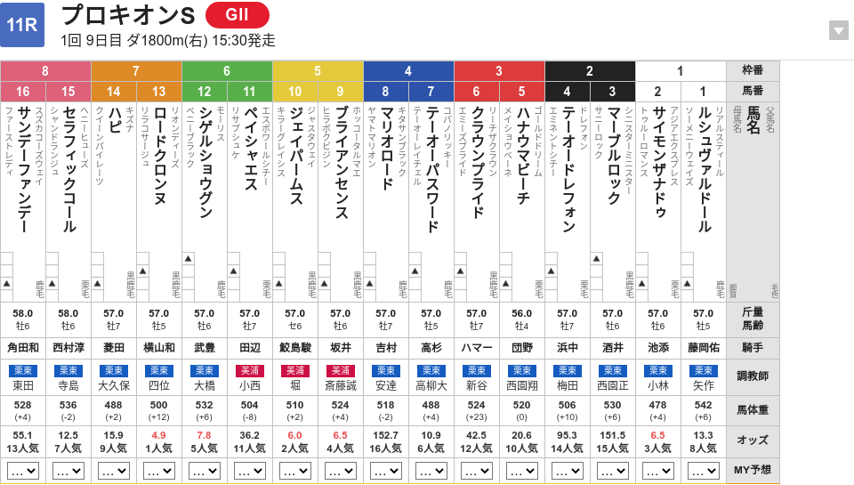

## 4. 単勝予測結果

### 【小倉牝馬ステークス(GⅢ) 2026/01/24(土)】

| 枠番 | 馬番 | 人気 | オッズ | 馬名 | 騎手 | 調教師 | 予測タイム(sec) | 1_順位 | 1-3着内確率(%) | 2_順位 | ﾀﾞｰｸﾎｰｽ確率(%) | 3_順位 |
| --- | --- | --- | --- | --- | --- | --- | --- | --- | --- | --- | --- | --- |
| 1 | 1 | 3 | 8.4 | テレサ | 松山弘平 | 杉山晴紀 | 126.5 | 9 | 29.1 | 3 | 0.5 | 16 |
| 1 | 2 | 13 | 83.9 | ブラウンラチェット | 武藤雅 | 手塚貴久 | 126.0 | 6 | 10.6 | 12 | 60.1 | 4 |
| 2 | 3 | 6 | 10.3 | フレミングフープ | 杉原誠人 | 友道康夫 | 126.2 | 7 | 21.9 | 5 | 0.5 | 17 |
| 2 | 4 | 10 | 23.2 | クリノメイ | 酒井学 | 須貝尚介 | 126.4 | 8 | 16.0 | 8 | 45.4 | 6 |
| 3 | 5 | 12 | 83.5 | アレナリア | 松本大輝 | 西園翔太 | 129.6 | 15 | 5.7 | 14 | 54.6 | 5 |
| 3 | 6 | 11 | 60.2 | フィールシンパシー | 横山琉人 | 小島茂之 | 132.4 | 17 | 4.4 | 15 | 65.0 | 2 |
| 4 | 7 | 7 | 13.9 | インヴォーグ | 松若風馬 | 福永祐一 | 126.7 | 10 | 18.1 | 6 | 0.8 | 12 |
| 4 | 8 | 2 | 3.7 | ココナッツブラウン | 北村友一 | 上村洋行 | 117.3 | 2 | 30.2 | 2 | 0.6 | 14 |
| 5 | 9 | 4 | 9.7 | パレハ | 鮫島克駿 | 新谷功一 | 128.0 | 13 | 14.8 | 10 | 0.5 | 18 |
| 5 | 10 | 18 | 325.0 | タクシンイメル | 高倉稜 | 武英智 | 132.0 | 16 | 1.8 | 18 | 20.7 | 7 |

[output cut: 8 more lines]

### 【アメリカジョッキーC(GⅡ) 2026/01/25(日)】

| 枠番 | 馬番 | 人気 | オッズ | 馬名 | 騎手 | 調教師 | 予測タイム(sec) | 1_順位 | 1-3着内確率(%) | 2_順位 | ﾀﾞｰｸﾎｰｽ確率(%) | 3_順位 |
| --- | --- | --- | --- | --- | --- | --- | --- | --- | --- | --- | --- | --- |
| 1 | 1 | 8 | 20.0 | チャックネイト | Ｒ．キング | 堀宣行 | 142.0 | 13.0 | 9.2 | 10 | 1.5 | 9 |
| 1 | 2 | 15 | 220.2 | ホウオウノーサイド | 杉原誠人 | 奥村武 | 142.5 | 16.0 | 5.9 | 12 | 18.5 | 4 |
| 2 | 3 | 5 | 8.5 | マイネルエンペラー | 戸崎圭太 | 清水久詞 | 133.6 | 2.0 | 26.0 | 2 | 0.4 | 16 |
| 2 | 4 | 2 | 5.4 | ジョバンニ | 松山弘平 | 杉山晴紀 | 139.4 | 7.0 | 18.0 | 5 | 0.6 | 11 |
| 3 | 5 | 6 | 10.7 | マテンロウレオ | 横山典弘 | 昆貢 | 136.8 | 6.0 | 32.0 | 1 | 0.6 | 12 |
| 3 | 6 | 16 | 233.9 | サンストックトン | 松岡正海 | 堀内岳志 | 142.3 | 15.0 | 4.8 | 13 | 21.7 | 2 |
| 4 | 7 | 13 | 145.0 | マイネルメモリー | 佐々木大輔 | 宮徹 | 135.6 | 4.0 | 10.3 | 9 | 65.6 | 1 |
| 4 | 8 | 12 | 105.6 | アウスヴァール | 古川吉洋 | 昆貢 | 142.2 | 14.0 | 3.2 | 14 | 10.6 | 8 |
| 5 | 9 | 3 | 5.4 | ショウヘイ | 川田将雅 | 友道康夫 | 141.5 | 8.5 | 20.8 | 3 | 0.4 | 14 |
| 5 | 10 | 9 | 33.2 | ノースブリッジ | 岩田康誠 | 奥村武 | 136.2 | 5.0 | 10.6 | 8 | 15.2 | 5 |

[output cut: 6 more lines]

| 枠番 | 馬番 | 人気 | オッズ | 馬名 | 騎手 | 調教師 | 予測タイム(sec) | 1_順位 | 1-3着内確率(%) | 2_順位 | ﾀﾞｰｸﾎｰｽ確率(%) | 3_順位 |
| --- | --- | --- | --- | --- | --- | --- | --- | --- | --- | --- | --- | --- |
| 1 | 1 | 8 | 13.8 | ルシュヴァルドール | 藤岡佑介 | 矢作芳人 | 91.3 | 15 | 8.9 | 11 | 0.8 | 11 |
| 1 | 2 | 4 | 6.7 | サイモンザナドゥ | 池添謙一 | 小林真也 | 89.0 | 10 | 12.2 | 7 | 0.4 | 15 |
| 2 | 3 | 15 | 140.1 | マーブルロック | 酒井学 | 西園正都 | 80.3 | 2 | 11.1 | 8 | 44.9 | 1 |
| 2 | 4 | 14 | 97.6 | テーオードレフォン | 浜中俊 | 梅田智之 | 89.4 | 11 | 7.9 | 12 | 33.2 | 3 |
| 3 | 5 | 10 | 20.5 | ハナウマビーチ | 団野大成 | 西園翔太 | 90.6 | 14 | 10.6 | 9 | 43.2 | 2 |
| 3 | 6 | 12 | 39.7 | クラウンプライド | Ｔ．ハマーハンセン | 新谷功一 | 90.1 | 13 | 4.0 | 13 | 31.0 | 4 |
| 4 | 7 | 6 | 10.6 | テーオーパスワード | 高杉吏麒 | 高柳大輔 | 81.3 | 5 | 24.4 | 5 | 1.1 | 10 |
| 4 | 8 | 16 | 158.2 | マリオロード | 吉村誠之助 | 安達昭夫 | 88.5 | 7 | 2.6 | 14 | 22.0 | 6 |
| 5 | 9 | 3 | 6.6 | ブライアンセンス | 坂井瑠星 | 斎藤誠 | 89.8 | 12 | 30.8 | 4 | 0.4 | 16 |
| 5 | 10 | 2 | 6.0 | ジェイパームス | 鮫島克駿 | 堀宣行 | 80.3 | 2 | 40.8 | 1 | 0.4 | 14 |

[output cut: 6 more lines]

## 5. 人気と着順の乖離率推移

### 【アメリカジョッキーC_1990y_2019y】

[interactive chart not shown]

### 【プロキオンステークス_1996y_2019y】

[interactive chart not shown]

### 【アメリカジョッキーC_1990y_2019y】

| No | 開催年 | 不整合率(%) | 頭数 | 人気別着順(1-3位) | 人気別着順(全体) |
| --- | --- | --- | --- | --- | --- |
| 30 | 2019 | 24.1 | 11頭 | 7-1-5 | 7\|1\|5\|2\|4\|3\|9\|6\|10\|8\|11 |
| 29 | 2018 | 39.2 | 11頭 | 2-1-8 | 2\|1\|8\|9\|6\|5\|4\|7\|10\|11\|3 |
| 28 | 2017 | 34.3 | 16頭 | 7-1-3 | 7\|1\|3\|5\|6\|9\|16\|11\|15\|8\|13\|10\|2\|12\|17\|14 |
| 27 | 2016 | 41.9 | 15頭 | 2-3-7 | 2\|3\|7\|5\|6\|8\|12\|13\|9\|1\|4\|15\|10\|16\|14 |
| 26 | 2015 | 45.2 | 17頭 | 4-7-2 | 4\|7\|2\|10\|11\|8\|1\|6\|16\|9\|14\|3\|12\|15\|5\|13\|17 |
| 25 | 2014 | 32.2 | 16頭 | 2-11-6 | 2\|11\|6\|1\|10\|7\|15\|13\|8\|3\|9\|4\|5\|12\|16\|14 |
| 24 | 2013 | 58.2 | 12頭 | 3-5-2 | 3\|5\|2\|4\|12\|6\|1\|9\|8\|11\|10\|7 |
| 23 | 2012 | 13.4 | 11頭 | 1-2-4 | 1\|2\|4\|9\|3\|7\|6\|11\|10\|5\|8 |
| 22 | 2011 | 26.8 | 11頭 | 1-6-3 | 1\|6\|3\|2\|10\|4\|11\|9\|8\|7\|5 |
| 21 | 2010 | 70.8 | 13頭 | 5-9-3 | 5\|9\|3\|4\|6\|2\|13\|12\|8\|11\|1\|7\|10 |

[output cut: 20 more lines]

### 【プロキオンステークス_1996y_2019y】

| No | 開催年 | 不整合率(%) | 頭数 | 人気別着順(1-3位) | 人気別着順(全体) |
| --- | --- | --- | --- | --- | --- |
| 24 | 2019 | 37.1 | 15頭 | 2-3-4 | 2\|3\|4\|6\|1\|9\|8\|7\|5\|14\|13\|15\|10\|12\|11 |
| 23 | 2018 | 24.0 | 14頭 | 5-1-2 | 5\|1\|2\|6\|10\|4\|3\|7\|11\|13\|8\|12\|9\|14 |
| 22 | 2017 | 39.3 | 15頭 | 5-1-6 | 5\|1\|6\|12\|7\|15\|9\|3\|14\|11\|13\|2\|10\|4\|8 |
| 21 | 2016 | 24.2 | 15頭 | 1-3-2 | 1\|3\|2\|5\|8\|7\|9\|10\|14\|13\|6\|11\|4\|15\|12 |
| 20 | 2015 | 47.1 | 16頭 | 4-2-8 | 4\|2\|8\|7\|6\|1\|5\|12\|11\|10\|15\|14\|9\|3\|16\|13 |
| 19 | 2014 | 13.0 | 16頭 | 1-2-10 | 1\|2\|10\|3\|12\|5\|7\|8\|4\|13\|9\|15\|11\|6\|16\|14 |
| 18 | 2013 | 26.7 | 16頭 | 2-5-1 | 2\|5\|1\|6\|3\|7\|8\|11\|4\|10\|9\|13\|12\|16\|15\|14 |
| 17 | 2012 | 27.3 | 16頭 | 12-4-1 | 12\|4\|1\|10\|2\|3\|9\|16\|6\|7\|8\|5\|15\|11\|14\|13 |
| 16 | 2011 | 38.2 | 16頭 | 9-3-1 | 9\|3\|1\|14\|15\|2\|7\|10\|5\|13\|4\|16\|11\|6\|12\|8 |
| 15 | 2010 | 36.2 | 16頭 | 4-2-1 | 4\|2\|1\|5\|6\|11\|9\|14\|3\|15\|7\|13\|10\|12\|16\|8 |

[output cut: 14 more lines]

## 6. 1-3番人気馬の着順分類予測

### 【アメリカジョッキーC】

| 分類 | 凡例 | 発生確率(%) | 当該レース | 当該レースランク | 直近1年間 |
| --- | --- | --- | --- | --- | --- |
| 4: 1,2番人気のみ (4_pop12) | 1 \| 2 \| * | 16.4 | 1.98 | 1.98 | 0.00 |
| 1: 1番人気のみ (1_pop1) | 1 \| * \| * | 15.9 | 0.57 | 0.57 | 0.32 |
| 8: 1,2,3番人気すべて着外 (8_darkhorse) | * \| * \| * | 14.5 | 2.59 | 2.59 | 0.00 |
| 5: 1,3番人気のみ (5_pop13) | 1 \| 3 \| * | 14.0 | 0.84 | 0.84 | 0.00 |
| 3: 3番人気のみ (3_pop3) | 3 \| * \| * | 11.6 | 4.14 | 4.14 | 0.00 |
| 2: 2番人気のみ (2_pop2) | 2 \| * \| * | 11.0 | 0.57 | 0.57 | 0.00 |
| 6: 2,3番人気のみ (6_pop23) | 2 \| 3 \| * | 9.0 | 0.54 | 0.54 | 0.18 |
| 7: 1,2,3番人気すべて着内 (7_pop123) | 1 \| 2 \| 3 | 7.6 | 2.71 | 2.71 | 0.00 |

### 【プロキオンステークス】

| 分類 | 凡例 | 発生確率(%) | 当該レース | 当該レースランク | 直近1年間 |
| --- | --- | --- | --- | --- | --- |
| 6: 2,3番人気のみ (6_pop23) | 2 \| 3 \| * | 16.3 | 0.70 | 0.70 | 0.33 |
| 4: 1,2番人気のみ (4_pop12) | 1 \| 2 \| * | 15.3 | 0.66 | 0.66 | 0.00 |
| 1: 1番人気のみ (1_pop1) | 1 \| * \| * | 15.2 | 0.51 | 0.51 | 0.30 |
| 8: 1,2,3番人気すべて着外 (8_darkhorse) | * \| * \| * | 13.6 | 0.00 | 0.00 | 0.00 |
| 5: 1,3番人気のみ (5_pop13) | 1 \| 3 \| * | 12.5 | 1.87 | 1.87 | 0.00 |
| 2: 2番人気のみ (2_pop2) | 2 \| * \| * | 10.1 | 1.51 | 1.51 | 0.00 |
| 3: 3番人気のみ (3_pop3) | 3 \| * \| * | 9.9 | 3.00 | 3.00 | 0.00 |
| 7: 1,2,3番人気すべて着内 (7_pop123) | 1 \| 2 \| 3 | 7.1 | 1.06 | 1.06 | 0.00 |

## 7. 3連複予測結果

### 【小倉牝馬ステークス(GⅢ) 2026/01/24(土)】

| 分類 | 馬番 | 枠番 | 人気 | 平均予測タイム(sec) | 1-3着内確率(%) | ﾀﾞｰｸﾎｰｽ確率(%) | 馬名 | 騎手 | 調教師 |
| --- | --- | --- | --- | --- | --- | --- | --- | --- | --- |
| 6: 2,3番人気のみ (6_pop23) | 8-1-16 | 4-1-8 | 2-3-8 | 120.37 | 3.18 | 0.00 | ココナッツブラウン \| テレサ \| ボンドガール | 北村友一 \| 松山弘平 \| 丹内祐次 | 上村洋行 \| 杉山晴紀 \| 手塚貴久 |
| 4: 1,2番人気のみ (4_pop12) | 17-8-16 | 8-4-8 | 1-2-8 | 117.30 | 2.64 | 0.00 | ジョスラン \| ココナッツブラウン \| ボンドガール | Ｃ．ルメール \| 北村友一 \| 丹内祐次 | 鹿戸雄一 \| 上村洋行 \| 手塚貴久 |
| 5: 1,3番人気のみ (5_pop13) | 17-1-16 | 8-1-8 | 1-3-8 | 120.37 | 2.55 | 0.00 | ジョスラン \| テレサ \| ボンドガール | Ｃ．ルメール \| 松山弘平 \| 丹内祐次 | 鹿戸雄一 \| 杉山晴紀 \| 手塚貴久 |
| 2: 2番人気のみ (2_pop2) | 8-3-16 | 4-2-8 | 2-6-8 | 120.27 | 2.39 | 0.00 | ココナッツブラウン \| フレミングフープ \| ボンドガール | 北村友一 \| 杉原誠人 \| 丹内祐次 | 上村洋行 \| 友道康夫 \| 手塚貴久 |
| 3: 3番人気のみ (3_pop3) | 1-3-16 | 1-2-8 | 3-6-8 | 123.33 | 2.31 | 0.00 | テレサ \| フレミングフープ \| ボンドガール | 松山弘平 \| 杉原誠人 \| 丹内祐次 | 杉山晴紀 \| 友道康夫 \| 手塚貴久 |
| 7: 1,2,3番人気すべて着内 (7_pop123) | 17-8-1 | 8-4-1 | 1-2-3 | 120.37 | 2.12 | 0.00 | ジョスラン \| ココナッツブラウン \| テレサ | Ｃ．ルメール \| 北村友一 \| 松山弘平 | 鹿戸雄一 \| 上村洋行 \| 杉山晴紀 |
| 2: 2番人気のみ (2_pop2) | 8-7-16 | 4-4-8 | 2-7-8 | 120.43 | 1.98 | 0.00 | ココナッツブラウン \| インヴォーグ \| ボンドガール | 北村友一 \| 松若風馬 \| 丹内祐次 | 上村洋行 \| 福永祐一 \| 手塚貴久 |
| 2: 2番人気のみ (2_pop2) | 8-15-16 | 4-7-8 | 2-5-8 | 122.57 | 1.95 | 0.00 | ココナッツブラウン \| レディーヴァリュー \| ボンドガール | 北村友一 \| 団野大成 \| 丹内祐次 | 上村洋行 \| 小林真也 \| 手塚貴久 |
| 6: 2,3番人気のみ (6_pop23) | 8-1-3 | 4-1-2 | 2-3-6 | 123.33 | 1.92 | 0.00 | ココナッツブラウン \| テレサ \| フレミングフープ | 北村友一 \| 松山弘平 \| 杉原誠人 | 上村洋行 \| 杉山晴紀 \| 友道康夫 |
| 1: 1番人気のみ (1_pop1) | 17-3-16 | 8-2-8 | 1-6-8 | 120.27 | 1.91 | 0.00 | ジョスラン \| フレミングフープ \| ボンドガール | Ｃ．ルメール \| 杉原誠人 \| 丹内祐次 | 鹿戸雄一 \| 友道康夫 \| 手塚貴久 |

[output cut: 806 more lines]

### 【アメリカジョッキーC(GⅡ) 2026/01/25(日)】

| 分類 | 馬番 | 枠番 | 人気 | 平均予測タイム(sec) | 1-3着内確率(%) | ﾀﾞｰｸﾎｰｽ確率(%) | 馬名 | 騎手 | 調教師 |
| --- | --- | --- | --- | --- | --- | --- | --- | --- | --- |
| 3: 3番人気のみ (3_pop3) | 9-3-5 | 5-2-3 | 3-5-6 | 137.30 | 1.74 | 0.00 | ショウヘイ \| マイネルエンペラー \| マテンロウレオ | 川田将雅 \| 戸崎圭太 \| 横山典弘 | 友道康夫 \| 清水久詞 \| 昆貢 |
| 1: 1番人気のみ (1_pop1) | 14-3-5 | 7-2-3 | 1-5-6 | 134.10 | 1.50 | 0.00 | ドゥラドーレス \| マイネルエンペラー \| マテンロウレオ | Ｃ．ルメール \| 戸崎圭太 \| 横山典弘 | 宮田敬介 \| 清水久詞 \| 昆貢 |
| 2: 2番人気のみ (2_pop2) | 4-3-5 | 2-2-3 | 2-5-6 | 136.60 | 1.50 | 0.00 | ジョバンニ \| マイネルエンペラー \| マテンロウレオ | 松山弘平 \| 戸崎圭太 \| 横山典弘 | 杉山晴紀 \| 清水久詞 \| 昆貢 |
| 8: 1,2,3番人気すべて着外 (8_darkhorse) | 3-5-15 | 2-3-8 | 5-6-7 | 137.30 | 1.46 | 0.00 | マイネルエンペラー \| マテンロウレオ \| ファウストラーゼン | 戸崎圭太 \| 横山典弘 \| 横山武史 | 清水久詞 \| 昆貢 \| 須貝尚介 |
| 8: 1,2,3番人気すべて着外 (8_darkhorse) | 12-3-5 | 6-2-3 | 4-5-6 | 137.37 | 1.30 | 0.00 | ディマイザキッド \| マイネルエンペラー \| マテンロウレオ | 岩田望来 \| 戸崎圭太 \| 横山典弘 | 清水英克 \| 清水久詞 \| 昆貢 |
| 5: 1,3番人気のみ (5_pop13) | 14-9-5 | 7-5-3 | 1-3-6 | 136.73 | 1.21 | 0.00 | ドゥラドーレス \| ショウヘイ \| マテンロウレオ | Ｃ．ルメール \| 川田将雅 \| 横山典弘 | 宮田敬介 \| 友道康夫 \| 昆貢 |
| 6: 2,3番人気のみ (6_pop23) | 4-9-5 | 2-5-3 | 2-3-6 | 139.23 | 1.20 | 0.00 | ジョバンニ \| ショウヘイ \| マテンロウレオ | 松山弘平 \| 川田将雅 \| 横山典弘 | 杉山晴紀 \| 友道康夫 \| 昆貢 |
| 3: 3番人気のみ (3_pop3) | 9-5-15 | 5-3-8 | 3-6-7 | 139.93 | 1.17 | 0.00 | ショウヘイ \| マテンロウレオ \| ファウストラーゼン | 川田将雅 \| 横山典弘 \| 横山武史 | 友道康夫 \| 昆貢 \| 須貝尚介 |
| 4: 1,2番人気のみ (4_pop12) | 14-4-5 | 7-2-3 | 1-2-6 | 136.03 | 1.04 | 0.00 | ドゥラドーレス \| ジョバンニ \| マテンロウレオ | Ｃ．ルメール \| 松山弘平 \| 横山典弘 | 宮田敬介 \| 杉山晴紀 \| 昆貢 |
| 3: 3番人気のみ (3_pop3) | 9-12-5 | 5-6-3 | 3-4-6 | 140.00 | 1.04 | 0.00 | ショウヘイ \| ディマイザキッド \| マテンロウレオ | 川田将雅 \| 岩田望来 \| 横山典弘 | 友道康夫 \| 清水英克 \| 昆貢 |

[output cut: 550 more lines]

| 分類 | 馬番 | 枠番 | 人気 | 平均予測タイム(sec) | 1-3着内確率(%) | ﾀﾞｰｸﾎｰｽ確率(%) | 馬名 | 騎手 | 調教師 |
| --- | --- | --- | --- | --- | --- | --- | --- | --- | --- |
| 2: 2番人気のみ (2_pop2) | 10-12-15 | 5-6-8 | 2-5-7 | 82.57 | 5.61 | 0.00 | ジェイパームス \| シゲルショウグン \| セラフィックコール | 鮫島克駿 \| 武豊 \| 西村淳也 | 堀宣行 \| 大橋勇樹 \| 寺島良 |
| 6: 2,3番人気のみ (6_pop23) | 10-9-15 | 5-5-8 | 2-3-7 | 85.50 | 4.75 | 0.00 | ジェイパームス \| ブライアンセンス \| セラフィックコール | 鮫島克駿 \| 坂井瑠星 \| 西村淳也 | 堀宣行 \| 斎藤誠 \| 寺島良 |
| 6: 2,3番人気のみ (6_pop23) | 10-9-12 | 5-5-6 | 2-3-5 | 83.70 | 4.58 | 0.00 | ジェイパームス \| ブライアンセンス \| シゲルショウグン | 鮫島克駿 \| 坂井瑠星 \| 武豊 | 堀宣行 \| 斎藤誠 \| 大橋勇樹 |
| 3: 3番人気のみ (3_pop3) | 9-12-15 | 5-6-8 | 3-5-7 | 85.73 | 4.25 | 0.00 | ブライアンセンス \| シゲルショウグン \| セラフィックコール | 坂井瑠星 \| 武豊 \| 西村淳也 | 斎藤誠 \| 大橋勇樹 \| 寺島良 |
| 2: 2番人気のみ (2_pop2) | 10-7-15 | 5-4-8 | 2-6-7 | 82.67 | 3.75 | 0.00 | ジェイパームス \| テーオーパスワード \| セラフィックコール | 鮫島克駿 \| 高杉吏麒 \| 西村淳也 | 堀宣行 \| 高柳大輔 \| 寺島良 |
| 2: 2番人気のみ (2_pop2) | 10-12-7 | 5-6-4 | 2-5-6 | 80.87 | 3.62 | 0.00 | ジェイパームス \| シゲルショウグン \| テーオーパスワード | 鮫島克駿 \| 武豊 \| 高杉吏麒 | 堀宣行 \| 大橋勇樹 \| 高柳大輔 |
| 8: 1,2,3番人気すべて着外 (8_darkhorse) | 12-7-15 | 6-4-8 | 5-6-7 | 82.90 | 3.36 | 0.00 | シゲルショウグン \| テーオーパスワード \| セラフィックコール | 武豊 \| 高杉吏麒 \| 西村淳也 | 大橋勇樹 \| 高柳大輔 \| 寺島良 |
| 6: 2,3番人気のみ (6_pop23) | 10-9-7 | 5-5-4 | 2-3-6 | 83.80 | 3.06 | 0.00 | ジェイパームス \| ブライアンセンス \| テーオーパスワード | 鮫島克駿 \| 坂井瑠星 \| 高杉吏麒 | 堀宣行 \| 斎藤誠 \| 高柳大輔 |
| 3: 3番人気のみ (3_pop3) | 9-7-15 | 5-4-8 | 3-6-7 | 85.83 | 2.84 | 0.00 | ブライアンセンス \| テーオーパスワード \| セラフィックコール | 坂井瑠星 \| 高杉吏麒 \| 西村淳也 | 斎藤誠 \| 高柳大輔 \| 寺島良 |
| 4: 1,2番人気のみ (4_pop12) | 13-10-15 | 7-5-8 | 1-2-7 | 82.33 | 2.77 | 0.00 | ロードクロンヌ \| ジェイパームス \| セラフィックコール | 横山和生 \| 鮫島克駿 \| 西村淳也 | 四位洋文 \| 堀宣行 \| 寺島良 |

[output cut: 550 more lines]

## 8. 直近の全レース情報

[output not shown]

[output cut: 8 more lines]